# Comparing starting values

Ben Smith

6/4/2018

I previously found that although my model could under some circumstances produce reasonable estimates using 3 chains, for a specific starting seed, further testing showed that this broke down for a 6-chain or 12-chain model, because not all chains starting in reasonable places.

So, I tried two different methods of specifying starting values based on the empirical data. First, a randomized method, and second, a bootstrapped distribution method.

```
## [1] "this version is deprecated, but is archived for records in case you want to see which version of the data was used to create the output."
```

```
## [1] 523.589
```

I compared starting values generated three different ways for a 10-subject, 12-run model.

Priors were the same informative priors used previously:

|  | Informative Priors |
| --- | --- |
| subject $\alpha_{\mu\mu}$ | -3.24 |
| subject $\alpha_{\mu\sigma}$ | 1.89 |
| subject $\alpha_{\sigma}$ | 2.07 |
| run $\alpha_{\sigma_{\gamma}}$ | 2.07 |
| subject $k_{\mu\mu}$ | -0.31 |
| subject $k_{\mu\sigma}$ | 0.12 |
| subject $k_{\sigma}$ | 0.51 |
| run $k_{\sigma_{\gamma}}$ | 0.35 |
| subject $\tau_{\mu\mu}$ | -1.75 |
| subject $\tau_{\mu\sigma}$ | 0.18 |
| subject $\tau_{\sigma}$ | 1.23 |
| run $\tau_{\sigma_{\gamma}}$ | 0.97 |

```
##  [1] 105 106 108 110 112 114 114 115 115 115
##  [1] 105 106 106 106 106 107 108 108 108 112
##  [1] 107 108 108 108 108 108 110 110 112 113
##  [1] 107 107 108 108 110 110 113 115 115 115
##  [1] 107 107 107 108 110 110 110 112 112 114
##  [1] 105 105 105 107 110 112 113 113 114 115
##  [1] 105 105 107 108 110 112 112 112 113 115
##  [1] 105 106 107 107 107 108 108 110 113 115
##  [1] 105 108 110 113 113 113 114 114 115 115
##  [1] 105 106 108 110 110 112 113 113 114 114
##  [1] 106 106 107 107 107 108 110 114 114 114
##  [1] 105 107 107 110 110 112 113 113 114 114
```

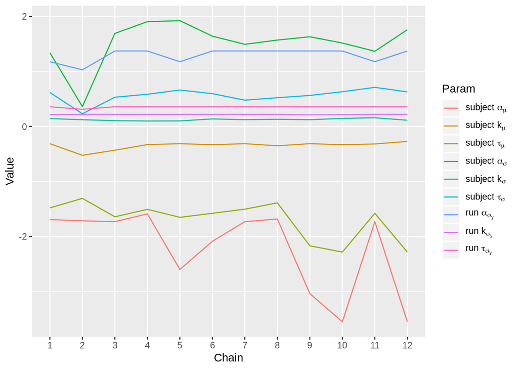

And the randomly determined initial were defined as such:

- subj $\alpha_{\mu} \sim \mathrm{norm}(-3.24,1.89)$
- subj $k_{\mu} \sim \mathrm{norm}(-0.31,0.12)$
- subj $tau_{\mu} \sim \mathrm{norm}(-1.75,0.18)$
- subj $\alpha_{\sigma} \sim |\mathrm{norm}(0,2.07)|$
- subj $k_{\sigma} \sim |\mathrm{norm}(0,0.51)|$
- subj $tau_{\sigma} \sim |\mathrm{norm}(0,1.23)|$
- run $\alpha_{\sigma\gamma} \sim |\mathrm{norm}(0,2.07)|$
- run $k_{\sigma\gamma} \sim |\mathrm{norm}(0,0.35)|$
- run $tau_{\sigma\gamma} \sim |\mathrm{norm}(0,0.97)|$

## Effiency

I wanted to measure efficiency for each parameter. At maximum efficiency, the effective sample size per chain-iteration is 1; lower efficiencies are degradations of this.

Efficiency per chain-iteration by parameter ($\rightarrow 1$ is better)

|  | Stan Automatic | Randomized | Bootstrapped |
| --- | --- | --- | --- |
| subject $\alpha_{\mu}$ | 0.01 | 0.50 | 0.49 |
| subject $k_{\mu}$ | 0.01 | 0.83 | 0.64 |
| subject $\tau_{\mu}$ | 0.01 | 0.60 | 0.58 |
| subject $\alpha_{\sigma}$ | 0.04 | 0.55 | 0.56 |
| subject $k_{\sigma}$ | 0.01 | 0.80 | 0.65 |
| subject $\tau_{\sigma}$ | 0.02 | 0.35 | 0.57 |
| run $\alpha_{\sigma_{\gamma}}$ | 0.66 | 1.00 | 1.00 |
| run $k_{\sigma_{\gamma}}$ | 0.01 | 1.00 | 1.00 |
| run $\tau_{\sigma_{\gamma}}$ | 0.03 | 1.00 | 1.00 |

Although the stan automatic values did not produce good results, both the random and bootstrapped initial values produced reasonable efficiency, although the bootstrapped initial values were not quite as good.

## Representativeness

Representativeness is measured by the Gelman-Rubin $\hat{R}$ statistic, and should ideally be lower than 1.05.

Gelman-Rubin $\hat{R}$ statistic by intialization method ($\hat{R}<1.05$ is acceptable)

|  | Stan Automatic | Randomized | Bootstrapped |
| --- | --- | --- | --- |
| subject $\alpha_{\mu}$ | 2.10 | 1.03 | 1.02 |
| subject $k_{\mu}$ | 3.98 | 1.01 | 1.01 |
| subject $\tau_{\mu}$ | 2.81 | 1.01 | 1.02 |
| subject $\alpha_{\sigma}$ | 1.19 | 1.03 | 1.01 |
| subject $k_{\sigma}$ | 29.72 | 1.00 | 1.01 |
| subject $\tau_{\sigma}$ | 1.73 | 1.05 | 1.02 |
| run $\alpha_{\sigma_{\gamma}}$ | 1.02 | 0.99 | 1.00 |
| run $k_{\sigma_{\gamma}}$ | 5.94 | 0.99 | 1.00 |
| run $\tau_{\sigma_{\gamma}}$ | 1.28 | 1.00 | 1.01 |

Both the randomized and bootstrapped initial values offered reasonable estimates, while the stan automatic values clearly could not converge properly on the target.

## Extending to a full group analysis

When extending the model to a full 54-subject group analysis, I found that the initial values produced would not allow the model to run. This was because I was generating random starting values at the subject and run level generated based on random distribution would occasionally be so far out of high-probability space that likelihood was zero.

In order to get around this problem, for both the randomized initial values and the bootstrapped initial values, I applied a pseudo-normal sampling method. Instead of taking random samples from the distributions, I used R’s |qnorm| function to define subject-level and run-level values as the set of equally-spaced quantiles between 2 standard deviations above and below the mean. This guaranteed both a normal distribution of values and avoided use of any extreme values which could potentially cause a zero likelihood initial proposal. The samples were scrambled so that within this constraint, the particular subject and run allocated to each quantile was entirely random.

This method does not apply to the raw empirical posterior sampling, because using this method, I obtained direct estimates of the data.

After this was applied, I was able to properly estimate initial values. However, these models appeared to have poor efficiency and calculations also took a long time. Thus I looked into ways to speed up calculation.

### Chains initializing

Furthermore, for the bootstrap and randomized distribution method, some chains regularly failed to initialize even though other chains correctly initialized. For a reliable estimation, I believe that we would need to ensure that all chains can initialize.

## Empirical distribution.

Currently I’m having problems with the empirical distribution. I did get it to correctly initialize for the 10 subjects, and notably, the empirical distribution initial values are able to reliably initialize all 12 chains for a 10-subject model. However, it doesn’t seem to be able to produce chains with any level of efficiency. I still need to look into this.

It also doesn’t initialize for the whole Group analysis. I suspect that may be because we were still using some badly-estimated run-level priors, and I am currently working on producing better run-level priors.

## Running single-level models

I modified my single-level modeling algorithm several times, in particular, to get good values for empirical distirbution startign values. To calculate averages for group-level priors, it was enough to just calculate a basic 3-chain model for each run and exclude any that would not converge. For calculating empirical samples to be used directly as initial values for the hierarchical model, I had to get a stable and accurate posterior distribution for every run. To achieve this, I:

- Initially tried a sample of 1000 warmup iterations, and 1000 further sampling iterations, across 6 chains.
- Where my computer could not complete calculation in 20 minutes, I aborted estimation and tried again (the median time was around 1-2 minutes). Usually this would result in a completed estimation on the second go.
- Where a posterior could be found, but $\\hat{R}$ values for one or more parameters were over 1.05, I would discard the entire estimation for that run and try again.
- For repeats either due to the 20-minute time-out, or due to poor $\\hat{R}$ values, I would repeat estimation for each run up to 9 times (10 times in total) until a stable posterior could be estimated within the timeout time.

## The evidence

I subsequently ran models using a revised inclusion definition (excluding trials with abnormally short reaction times; only including runs with accurately estimated run-level parameters). When applying this, counterintuitively, it was harder to get the model to run. We have some evidence from lbarl_hierarchical_extend_from_init_vals_v2_initialization_comparison.R about *initialization* - note that this doesn’t tell us anything about which models will complete accurate samples, just about which will initialize, i.e., the model can begin estimation because the initial values don’t yield an infinite gradient.